# Taller_Dia_3 slides

[figure not shown]

## Tenemos una hipotésis, la suma de las características multiplicados por los pesos de cada características. Si obtenemos el signo de esta suma, obtenemos el resultado de la hipotésis o predicción.

#### $$ h(x) = signo(\sum_{i=0}^{m} x_i \cdot w_i)$$

## Para el perceptrón las predicciones posibles son 1 y 0.

### Para evaluar la hipotésis, comparamos la predicción con el valor real por medio de una resta. Este resultado es el error de la hipotésis.

#### $$ error = d = y - h(x) $$

### Si la hipotésis y el valor real son iguales, la hipotésis fue correcta, no hay error!

#### $$ d = y - h(x) = (1) - (1) = 0 $$

### Si la hipotésis y el valor real son diferentes, la hipotésis se equivoco, y el error depende del valor real.

#### $$ d = y - h(x) = (0) - (1) = -1 $$

#### $$ d = y - h(x) = (1) - (0) = 1 $$

### El error representa la *dirección* en la que la hipotésis se equivocó!

## Para corregir la hipotésis hay que actualizar los pesos. Si los actualizamos según el error, podremos evitar el error en el futuro, ya que el peso seguira cambiando hasta que el error de 0.

#### $$ w' = w + (d)(x) $$

#### Por ejemplo, para $x = 1$, $y = 1$ y $w_0 = -1 $, $d_0 = 1$. Tenemos la actualización:

#### $$ w' = -1 + (1)(1) = 0 $$

## Y ahora:

#### $$ d_1 = y - Signo(xw) = 1 - Signo(0) = 1 - 1 = 0 $$

## De esta forma, al actualizar los pesos, se minimiza el error.

## Sin embargo, si los valores de X son muy grandes o los pesos ideales son numeros reales, actualizar de esta forma no es viable. Para esto utilizamos el **ritmo de aprendizaje ($\alpha$)** . Este ritmo reduce la fuerza con la que se actualiza $w$.

#### $ w' = w + \alpha(d \cdot x) $

#### En el ejemplo anterior, para $\alpha = 0.1$:

#### $ w' = -1 + (0.1)(1)(1) = -0.9 $

## Esto hace que dure más en llegar a minimizar el error, en este caso, pero permite más flexibilidad para llegar a una hipotésis optima. $\alpha$ debe ser un numero menor que 1.

# TALLER MACHINE LEARNING DIA 3

[figure not shown]

# Modelos de Machine Learning y su Validación

## Existen distintos tipos de modelos de Machine Learning, cada uno con su propia hipotésis, forma de medir su rendimiento y optimización. Veamos algunos de estos:

[figure not shown]

## Modelos Geometricos.

### Son aquellos cuyo objetivo es asemejar los datos a una linea o curva.

[figure not shown]

## Modelos de Arbol

### Son aquellos que modelan los datos según condiciones de los mismos.

[figure not shown]

## Modelos de Instancia.

### Son aquellos que agrupan los datos, y usan los datos completos para hacer predicciones.

[figure not shown]

# Regresión Lineal

### Es un modelo que asume que la relación entre $n$ variables explicativas o características y una variable dependiente o explicada se puede modelar por medio de una linea.

[figure not shown]

### Este modelo tiene como tarea una **regresión**, lo que significa que como resultado de la hipotésis, obtenemos un valor continuo. Ejemplo: Un precio, una duración, un indice, entre otros.

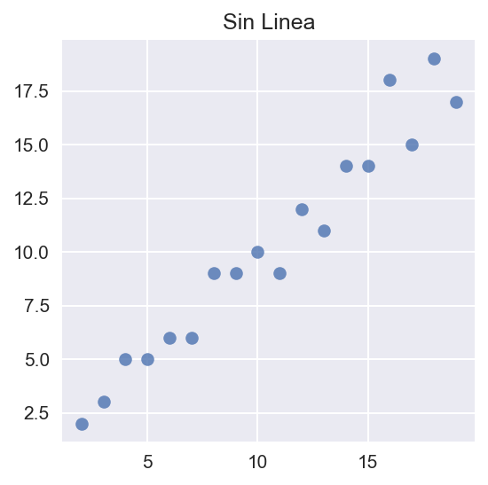

```python
np.random.seed(77)
x = np.arange(2,20)
y = np.array([n + np.random.choice(3, 1)  if n % 2 == 0 else n - np.random.choice(3, 1) for n in x])
sns.regplot(x,y,fit_reg = False)
plt.title('Sin Linea')
```

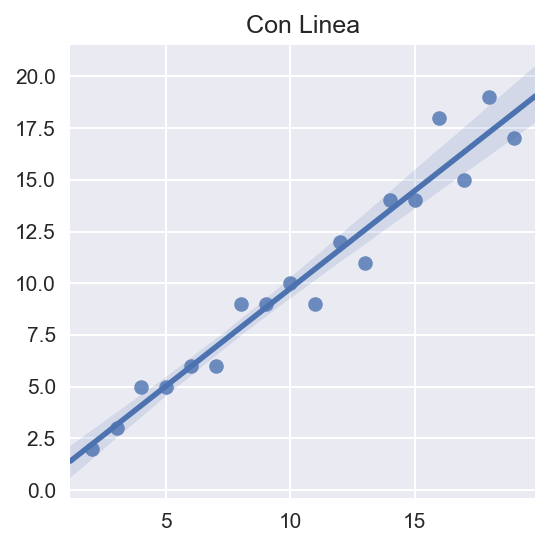

```python
sns.regplot(x,y.ravel())
plt.title('Con Linea')
```

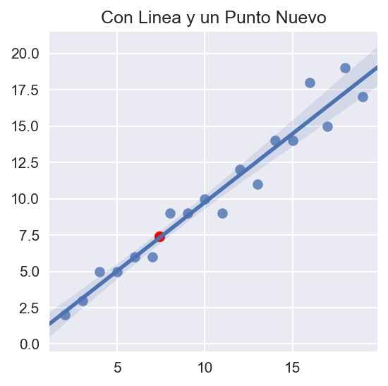

```python
sns.regplot(x,y.ravel())
plt.scatter(7.4,7.4,c = 'red')
plt.title('Con Linea y un Punto Nuevo')
```

# Hipotésis

## La hipotésis de regresión lineal es la suma ponderada vista anteriormente.

#### $$ h(x) = X \cdot w^T $$

# Función de costo (Error)

### La función de costo nos dice que tan lejos estuvo la hipotésis del valor real. Mientras más lejos esté la predicción, mayor el error. Para tener la mejor hipotésis, necesitamos minimizar el error. En el caso de regresión, el error es la diferencia entre el valor real y la hipotésis, tambien conocido como el **residuo**.

#### $$ r = y - h(x) $$

### Pero, esto solo nos dice que tanto se equivocó la hipotésis para un ejemplo. ¿Cómo podemos saber que tan buena fue la hipotésis en general?

### Podemos calcular el residuo para todos los ejemplos. Para saber que tan buena fue la hipotésis para todos los datos, podemos calcular el promedio de la suma de los errores cuadrados:

#### $$ J(w) = MSE = \frac{1}{2m}\sum_{i=0}^{m} r_i^2 $$

### En forma vectorial se puede representar como:

#### $$ J(w) = MSE = \frac{1}{2m} r \cdot r^T $$

### Este calculo siempre da como resultado un numero positivo. Como podemos actualizar los pesos según la dirección del error si no la tenemos?

# Gradiente

#### Como llegamos al punto más alto de esta montaña?

[figure not shown]

### El gradiente representa la dirección que maximiza el valor de una función de la manera más rapida. Por ejemplo, si tenemos una función cuyos valores maximos están en negro, el gradiente representa las lineas azules:

[figure not shown]

### Como tenemos una función de error que queremos *minimizar*, si utilizamos la dirección opuesta al gradiente, llegaremos al valor *minimo* de una función.

# Descenso del Gradiente

### Como queremos minimizar el error, para actualizar los pesos w, calculamos el gradiente del error con respecto a w:

#### $$ \nabla J(w) =\frac{1}{m} (X^T \cdot (y - h(x)))$$

### Negamos el gradiante y lo multiplicamos por un ritmo de aprendizaje para suavizarlo.

#### $$ g = -\alpha \nabla J(w) $$

### Y actualizamos los pesos w con este resultado.

#### $$ w' = w + g $$

### Si repetimos este proceso una y otra vez, llegaremos al punto más bajo de la "montaña"

# Aplicación Regresión Lineal 1: Predecir ganancias según población del lugar.

### Una empresa quiere abrir una nueva sucursal en una nueva ciudad. Para sus ultimas sucursales, tienen la cantidad de habitantes del sitio y las ganancias que han obtenido del mismo. Quieren aproximar cuales serían sus ganancias en una ciudad dada su cantidad de habitantes. Vamos a crearles un modelo de regresión lineal para satisfacer esa necesidad.

[figure not shown]

# Aplicación Regresión Lineal 2: Predecir costo de una casa.

### Estas comprando una casa porque te quieres mudar, y un agente de bienes raices muy vivo te intenta vender una casa. Como no confias en esa persona, buscas información de precios de casas según el area que ocupa y la cantidad de habitaciones. Tu objetivo es crear un modelo de regresión lineal, para que no te dejes engañar con el precio.

[figure not shown]

# Regresión Logistica

### Es un modelo de clasificación que separar clases por medio de una linea.

[figure not shown]

### Es muy parecido al perceptron que vimos anteriormente, pero con ciertas diferencias.

# Hipotésis

### La hipotésis es casi igual a la del perceptron. Utiliza el calculo de una suma ponderada:

#### $$h(x) = \sum_{i=0}^{m} x_i \cdot w_i$$

### y una transformación a los datos muy diferente. *Por qué?*

### En el perceptrón al obtener el resultado, solo obteníamos dos números: 0 y 1. Por ende, al calcular el error, solo obteniamos 3 valores: -1,0 y 1. Esto resultaba en problemas al actualizar los pesos, ya que no sabíamos que tanto errabamos en la hipotésis, solo en que dirección. ¿Cómo podemos saber que tan cerca estuvimos de la respuesta correcta?

## Sigmoide

### La función sigmoide es una función que convierte casi cualquier numero a un número entre 0 y 1. Se representa de la siguiente manera:

#### $$ s = \frac{1}{1 + e^{-x}} $$

### O de manera gráfica:

[figure not shown]

### Para qué sirve el Sigmoide? Si una suma ponderada cualquiera, por ejemplo: z = 2, si pasamos esa suma al sigmoide obtendremos:

#### $$ s(2) = \frac{1}{1 + e^{-2}} = 0.8808 $$

### O -2:

#### $$ s(-2) = \frac{1}{1 + e^{2}} = 0.1192 $$

#### Lo cual modela una probabilidad! Podemos ver la hipotésis ahora como *la probabilidad de que este ejemplo sea verdadero (1)*. La hipotésis final seria:

#### $$ h(x) = \frac {1}{1 + e^{(X \ w^T)}} $$

# Costo

### Si como hipotésis tenemos la probabilidad de que el ejemplo pertenezca a la clase verdadera (1), el error sería que tan lejos está la probabilidad de la realidad. Para encontrar la diferencia entre $y$ y la hipotésis podemos utilizar el diferencial (o derivada) del sigmoide:

$$ J(w) = h(x)(1 - h(x)) $$

### Cuando $ y = 1 $:

$$ P(y = 1 \ | \ x) = h(x) $$

### Cuando $ y = 0 $:

$$ P(y = 0 \ | \ x) = 1 - h(x) $$

### Y podemos juntarlo como:

$$ P(y \ | \ x) = (h(x))^y (1 - h(x))^{1 - y}$$

### El objetivo de este costo es maximizar la probabilidad de que cada predicción pertenece a una clase, porque tecnicamente, estar 51% seguro de que una clase es positiva, da un resultado positivo, pero no es muy confiable. Para suavizar el calculo, podemos aplicar un logaritmo para eliminar los exponentes.

$$l(w) = log(P(y \ | \ x) = \\ y log(h(x)) + (1 - y)log( 1 - h(x)) $$

### En forma vectorial:

$$ l(w) = \frac{1}{m} \ y log(h(x))^T + (1 - y)log(1 - h(x))^T $$

### Y ya tenemos el costo de la hipotésis, que representa la inseguridad promedio que tiene el modelo sobre la predicción de cada ejemplo sobre su clase.

# Descenso del Gradiente.

### El gradiente de la función de costo de regresión logistica es exactamente igual que el de regresión lineal!

#### $$ \nabla J(w) =\frac{1}{m} (X^T \cdot (y - h(x)))$$

#### $$ g = -\alpha \nabla J(w) $$

#### $$ w' = w + g $$

### Igualmente, se repite el proceso hasta minimizar el error.

# Aplicación Regresión Logistica 1: Examén

### Quieres entrar a una universidad de Estados Unidos para hacer tu maestría, pero necesitas pasar el GRE. Logras obtener resultados de algunos estudiantes en su examen de Inglés y Matématicas, y si fueron admitidos o no. Quieres saber como influyen esas dos notas en la decisión de admisión, si solo importaran esos examenes para la admisión. Elaborar un modelo de Regresión Logistica con este proposito.

[figure not shown]

# Aplicación Regresión Logistica 2: QA de Microchips.

### Eres un personal de aseguramiento de calidad que le hace dos pruebas a unos microchips. Según los resultados de esas pruebas, apruebas el microchip o no. Tienes un historial de pruebas de microchips, y su aceptación. Para facilitarte el trabajo en el futuro, creaste un modelo de regresión logistica con esos datos.

[figure not shown]

# Validación de Modelos

### Todo este tiempo, hemos estado validando los modelos con datos de entrenamiento. Esto no es una buena práctica, ya que el objetivo del modelo es que funcione para datos que no ha visto. El modelo se entrena con los datos de ejemplo, se "acostumbra" a ellos. Esto puede causar que el modelo se "aprenda" los datos y no la función debajo de los mismos.

[figure not shown]

### Veamoslo en acción.

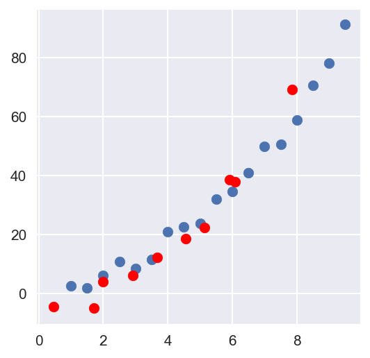

```python
np.random.seed(42)
x = np.arange(1,10,0.5)
y = (x ** 2 ) +  np.random.normal(0,3,len(x))
testx = np.random.rand(10) * 10
testy = (testx ** 2) + np.random.normal(0,4,len(testx))
plt.scatter(x,y)
plt.scatter(testx,testy,c = 'r')
```

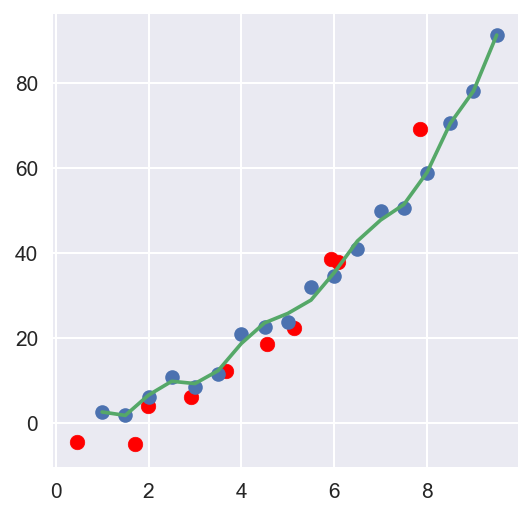

```python
z = np.polyfit(x, y, 12)
f = np.poly1d(z)
x_new = np.linspace(x[0],x[-1], len(x))
y_new = f(x_new)
plt.plot(x,y,'o', x_new, y_new)
plt.scatter(testx,testy,c = 'r')
```

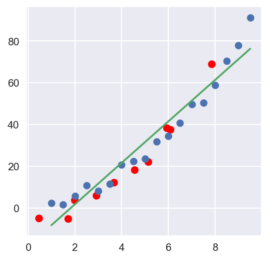

```python
z = np.polyfit(x, y, 1)
f = np.poly1d(z)
x_new = np.linspace(x[0],x[-1], len(x))
y_new = f(x_new)
plt.plot(x,y,'o', x_new, y_new)
plt.scatter(testx,testy,c = 'r')
```

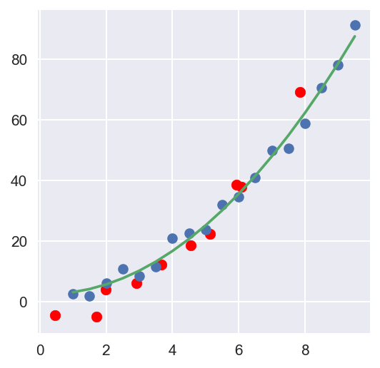

```python
z = np.polyfit(x, y, 2)
f = np.poly1d(z)
x_new = np.linspace(x[0],x[-1], len(x))
y_new = f(x_new)
plt.plot(x,y,'o', x_new, y_new)
plt.scatter(testx,testy,c = 'r')
```

## Bias vs. Variance

### El objetivo de los modelos de machine learning es poder generalizar afuera de sus datos de entrenamiento. Esto implica minimizar dos fuentes de error que están intrinsicamente relacionados. Este dilemma es conocido como el intercambio bias-variance, y es una parte fundamental de la validación de los modelos de Machine Learning.

### Bias: Es el error de las asunciones incorrectas del algoritmo de aprendizaje. Si el bias es alto, el algoritmo puede perderse de relaciones relevantes entre las variables (*underfitting*).

### Variance (Varianza): Es el error de al sensibilidad a pequeños cambios en los datos de entrenamiento. Si la varianza es alta, el modelo se aprenderá el *ruido* en vez de la relación entre las variables (*overfitting*).

### El modelo más generalizado tiene bias y varianza bajos.

## Bias vs. Variance

[figure not shown]

### Para poder validar el modelo y captar el bias-variance del mismo, dividimos los datos en dos: entrenamiento y prueba. Usamos la mayoria de los datos para entrenar, y el resto para validar.

## Curva de Aprendizaje.

### Al incrementar el tamaño de los datos de entrenamiento se ven comportamientos diferentes.

### Para un bias alto:

[figure not shown]

### Para un variance alto:

[figure not shown]

## Como combatir el bias?

- Mejorar los parametros del modelo.
- Agregar más columnas/ variables.
- Usar un modelo más complejo.

## Como combatir la varianza?

- Agregar más datos.
- Disminuir el numero de columnas/variables.
- Mejorar los parametros del modelo.
- Regular los pesos.

# Aplicación Validación: Venta de Casa.

### Luego de durar algunos años en tu casa, decides mudarte. Antes de mudarte, quieres vender la casa. Esta vez, haces un mejor estudio de las casas en los alrededores, y obtienes mucho más información. Creas un modelo de regresión, y lo validas bien para poder vender tu casa al mejor precio.

[figure not shown]